# WSMDP Carbohydrate Analysis

Lillian Hislop

4/8/2021

# 1 Introduction

This study focuses on the carbohydrate content and genetic associations within the Wisconsin Sweet Maize Diversity Panel (WSMDP). Sweet maize was derived from Teosinte, a wild and cultivated grass, by Indigenous Americans. It was and is used in all manners of dishes, as a sweetener and beverage. Sweet maize was an important cultural symbol, with the Aztecan god Centeōtl responsible for maize and sustinance. Sweet maize was traded and transported across North America by Indigenous peoples. Today, it is the third most eaten vegetable in the United States. Eating quality is the most important breeding factor in sweet maize, and the majority of the eating quality is derived from the carbohydrate composition of the kernels. By studying carbohydrate composition and associated genetics markers, this can lead, with further study, to breeders more finely controling their lines’ eating quality or quickly categorize the eating quality of their established germplasm.

# 2 Materials and Methods

The WSMDP consists of 437 sweet maize inbreds. They were grown in 2014 and 2015 in Ithica, New York and Madison, Wisconsin in a super block field layout. The number of samples in each environment were as follows:

```
##  2014New York 2014Wisconsin  2015New York 2015Wisconsin
##           753           854           793           424
```

A wide variety of endosperm mutants were represented:

```
## aeduwx  field     se    sh2   sh2i    su1
##     18     71    210    386    118   2021
```

Ears were harvested at eating stage, 400 growing degree days (GDD), flash frozen in liquid nitrogen, and lyophilized. Then all samples were finely ground and scanned on a Near Infared Spectroscopy machine. Ten percent of the samples were analyzed in wetlab for sugar content through an Megazyme assay kit and 100 samples were analyzed for starch content using a megazyme assay kit. Samples were grouped into three different pools based around water soluble polysaccharide (WSP) content to generate equations linking the carbohydrate content informed by the enzyme assays with the NIR spectroscopy wavelength data. The high WSP group (HWSP) was calibrated with samples with *sugary1* (*su1*) and *sugary enhancer* (*se*) endosperm mutant types. There were two versions of the low WSP groupings. The low WSP endosperm mutants include *shrunken2* (*sh2*), *shrunken2-intermediate* (*sh2i*), ae-dull-waxy (*aeduwx*), and field maize inbreds. In one grouping field maize inbreds were included in the calibration and in the other grouping field maize inbred lines were excluded from the calibrations and from analysis. These were the low WSP with field (LWSPWF) and low wsp with no field line (LWSPNF) groupings.The calibration equations were used to predict the carbohydrate content of the samples within each respective group, i.e. the predictions from the HWSP calibration equation were used to predict *su1* samples, and the prediction from the LWSPWF groupings were used to predict the *sh2i* samples.

# 3 Results

## 3.1 Equation Validation

A portion of the samples (57) had their carbohydrates were analyzed in both wetlab and predicted through NIR but were not used to calibrate the equation. These samples were used for validating the quality of the equation. This included 38 samples from Jared Zystros *se* dataset for the purpose of validation and 19 were from the WSMDP sample set.

With Field Equation Validation Statistics for all predicted Carbohydrates:

```
##           Carb     RMSEP       bias       SEE slope intercept    R2
## 1 Ave.Fructose 0.9566038 -0.5306743 0.8177216 1.280    -1.367 0.622
## 2  Ave.Glucose 1.0035922 -0.1463870 1.0200652 1.681    -2.902 0.660
## 3    Ave.Sucro 4.4008814 -2.4454381 3.7591681 0.964    -0.648 0.542
## 4    Ave.Total 5.0130877 -2.6405918 4.3780268 1.054    -2.360 0.790
## 5     Starch.y 3.2863269 -1.0213026 3.2091954 0.688     7.604 0.619
## 6   Total_Poly 2.9031175 -0.5711108 2.9243855 0.832    12.919 0.291
## 7        WSP.y 2.4192443 -0.5420903 2.4223352 1.130     4.230 0.690
```

Non Field Equation Validation Statistics for all predicted Carbohydrates:

```
##           Carb     RMSEP        bias       SEE slope intercept    R2
## 1 Ave.Fructose 0.8523528 -0.44270987 0.7558584 1.259    -1.167 0.615
## 2  Ave.Glucose 0.8999881 -0.06943315 0.9311781 1.652    -2.691 0.635
## 3    Ave.Sucro 2.2110760 -0.43629472 2.2494282 1.010    -0.554 0.598
## 4    Ave.Total 2.5104488 -0.28911055 2.5878824 1.037    -1.125 0.841
## 5     Starch.y 3.2823057 -1.79492392 2.8517863 0.491     9.512 0.322
## 6   Total_Poly 2.5351678 -1.80753914 1.8447074 0.941    11.287 0.329
## 7        WSP.y 2.2344831 -1.13280822 1.9987543 1.098     4.767 0.626
```

We found the RSquared values for all carbohydrate prediction abilities to be acceptable. The average prediction ability among all the carbohydrates in the WF group is 0.602.The r^2 value among the different datasets can be summarized as follows:

|  | WF All Wetlab Samples | NF All Wetlab Samples | WF Validation Wetlab Samples | NF Validaion Wetlab Samples | WF Validation Wetlab and Zystro Samples | NF Validation Wetlab and Zystro Samples |
| --- | --- | --- | --- | --- | --- | --- |
| Fructose | 0.494 | 0.498 | 0.771 | 0.824 | 0.622 | 0.615 |
| Glucose | 0.516 | 0.531 | 0.521 | 0.644 | 0.660 | 0.635 |
| Sucrose | 0.659 | 0.737 | 0.809 | 0.937 | 0.542 | 0.598 |
| Total Sugar | 0.706 | 0.795 | 0.834 | 0.947 | 0.790 | 0.841 |
| Starch | 0.609 | 0.689 | 0.845 | 0.735 | 0.619 | 0.322 |
| Total Polysaccharide | 0.612 | 0.688 | 0.896 | 0.907 | 0.291 | 0.329 |
| WSP | 0.703 | 0.677 | 0.867 | 0.915 | 0.690 | 0.626 |
| Average R^2 | 0.614 | 0.659 | 0.792 | 0.844 | 0.602 | 0.567 |

We found that the inclusion or exclusion of the field maize inbred lines did not have a significant impact on the predictive ability of the equation. Due to this finding, we used the with field calibrations for the remainder of the analysis. To demonstrate how the validation samples performed visually, we have included the following example:

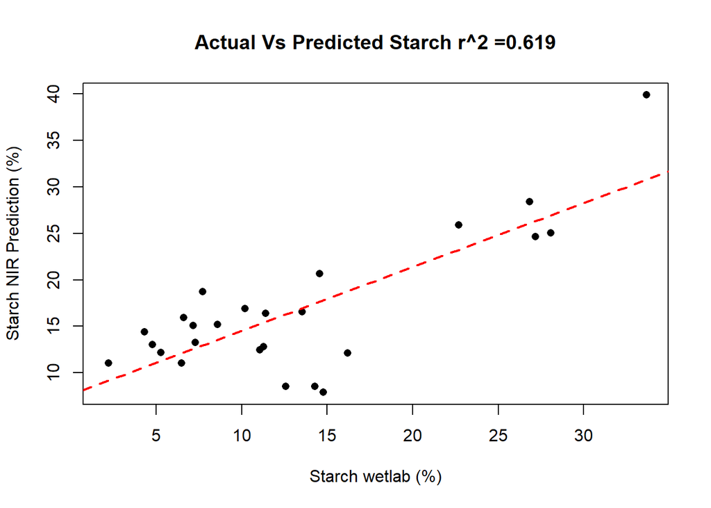

Figure 3.1: Wetlab vs Predicted Starch Percentage of validation wetlab and Zystro Validation set

## 3.2 Carbohydrate Distribution

Lets look at the distribution of carbohydrate content and correlations before cleaning for outliers. To further demonstrate the non-impact of including the field lines in the calibration set, we have compared the WF and NF carbohydrate distributions side by side

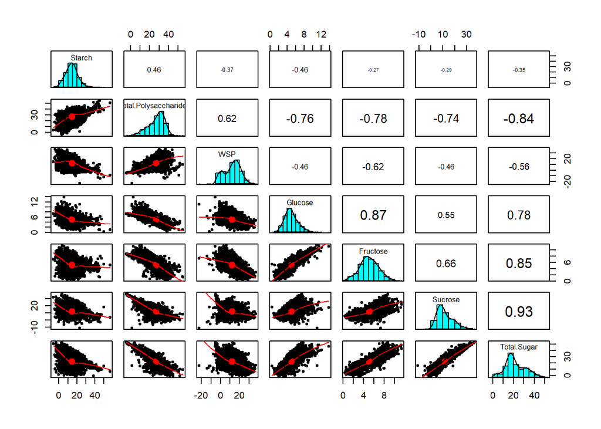

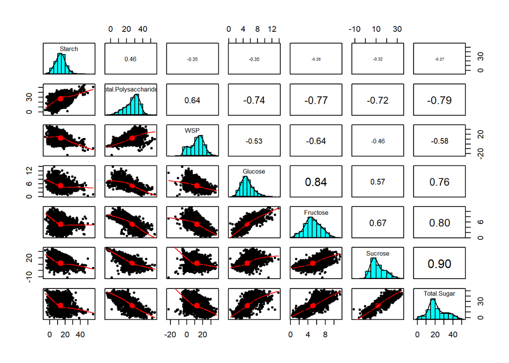

Figure 3.2: Distribution and Correlation of the Uncleaned Predicted Carbohydrates within the WF and NF grouping

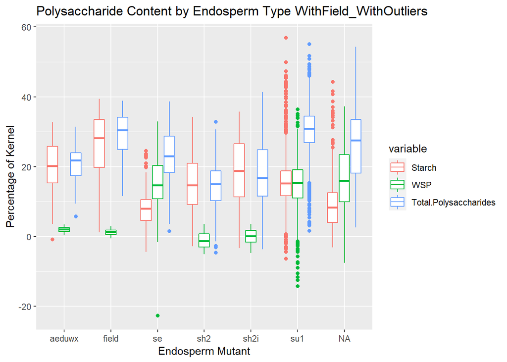

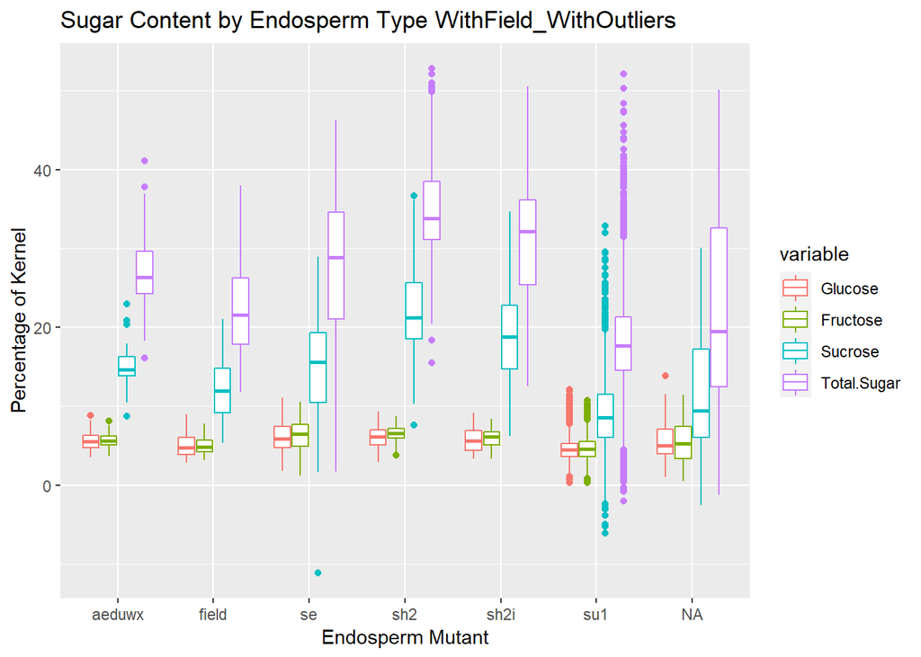

Figure 3.3: Distribution of Uncleaned Predicted Polysaccharide and Sugars within the WF grouping by endosperm type

[figure not shown]

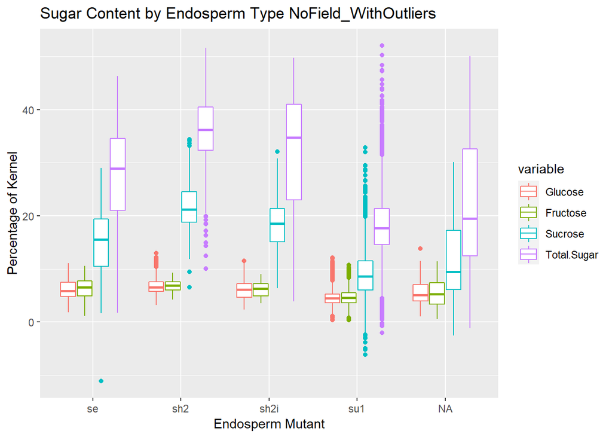

The data was cleaned by analyzing outliers below 0% for each carbohydrate type and either eliminating them if they were outliers compared to other samples of the same variety or by reclassifying the carbohydrate as 0% since < 0% is not biologically possible.

# 4 Conclusion